# Assingment

Amine Benseddiq

2023-03-10

### Analyzing the “2022 Fortune 1000”

### This dataset contains information on the top 1000 companies in the United States based on revenue.

### Top 10 Fortune 100 companies?

```r
#What are the top 10 Fortune 100 companies?
fortune_df[1:10,]
```

```
##               company rank rank_change  revenue  profit num..of.employees
## 1             Walmart    1           0 572754.0 13673.0           2300000
## 2              Amazon    2           0 469822.0 33364.0           1608000
## 3               Apple    3           0 365817.0 94680.0            154000
## 4          CVS Health    4           0 292111.0  7910.0            258000
## 5  UnitedHealth Group    5           0 287597.0 17285.0            350000
## 6         Exxon Mobil    6           4 285640.0 23040.0             63000
## 7  Berkshire Hathaway    7          -1 276094.0 89795.0            372000
## 8            Alphabet    8           1 257637.0 76033.0            156500
## 9            McKesson    9          -2 238228.0 -4539.0             67500
## 10  AmerisourceBergen   10          -2 213988.8  1539.9             40000
##         sector          city state newcomer ceo_founder ceo_woman profitable
## 1    Retailing   Bentonville    AR       no          no        no        yes
## 2    Retailing       Seattle    WA       no          no        no        yes
## 3   Technology     Cupertino    CA       no          no        no        yes
```

[output cut: 29 more lines]

```r
#Use str() to show and examine the structure of the dataset.

str(fortune_df)
```

```
## 'data.frame':    1000 obs. of  18 variables:
##  $ company          : chr  "Walmart" "Amazon" "Apple" "CVS Health" ...
##  $ rank             : int  1 2 3 4 5 6 7 8 9 10 ...
##  $ rank_change      : num  0 0 0 0 0 4 -1 1 -2 -2 ...
##  $ revenue          : num  572754 469822 365817 292111 287597 ...
##  $ profit           : num  13673 33364 94680 7910 17285 ...
##  $ num..of.employees: num  2300000 1608000 154000 258000 350000 ...
##  $ sector           : chr  "Retailing" "Retailing" "Technology" "Health Care" ...
##  $ city             : chr  "Bentonville" "Seattle" "Cupertino" "Woonsocket" ...
##  $ state            : chr  "AR" "WA" "CA" "RI" ...
##  $ newcomer         : chr  "no" "no" "no" "no" ...
##  $ ceo_founder      : chr  "no" "no" "no" "no" ...
##  $ ceo_woman        : chr  "no" "no" "no" "yes" ...
##  $ profitable       : chr  "yes" "yes" "yes" "yes" ...
##  $ prev_rank        : num  1 2 3 4 5 10 6 9 7 8 ...
##  $ CEO              : chr  "C. Douglas McMillon" "Andrew R. Jassy" "Timothy D. Cook" "Karen Lynch" ...
##  $ Website          : chr  "https://www.stock.walmart.com" "www.amazon.com" "www.apple.com" "https://www.cvshealth.com" ...
##  $ Ticker           : chr  "WMT" "AMZN" "AAPL" "CVS" ...
##  $ Market.Cap       : chr  "352037" "1202717" "2443962" "125204" ...
```

### Create and add a new column called “profit_margin” which calculates the profit margin for each company (profit/revenue).

```r
#Create and add a new column called "profit_margin"
#which calculates the profit margin for each company (profit/revenue).

profit_margin <- fortune_df$profit / fortune_df$revenue
fortune_df$profit_margin <- profit_margin
```

Create and add a new column called “revenue_per_employee” which calculates the revenue per employee for each company.

```r
#Create and add a new column called "revenue_per_employee"
#which calculates the revenue per employee for each company.

revenue_per_employee <- fortune_df$revenue / fortune_df$num..of.employees
fortune_df$revenue_per_employee <- revenue_per_employee
```

### Calculate the average profit_margin and revenue_per_employee.

```r
#calculate the average profit_margin and revenue_per_employee.
summary(profit_margin)
```

```
##     Min.  1st Qu.   Median     Mean  3rd Qu.     Max.     NA's
## -1.72717  0.03414  0.08768  0.10537  0.15588  1.45283        3
```

```r
summary(revenue_per_employee)
```

```
##     Min.  1st Qu.   Median     Mean  3rd Qu.     Max.     NA's
##  0.01927  0.29426  0.50857  1.09361  1.05724 21.93948        1
```

#### Create a dataframe called “tech_companies” containing all companies that have “Technology” as their industry.

```r
#Create a dataframe called "tech_companies" containing all
#companies that have "Technology" as their industry.

tech_companies <- subset(fortune_df,sector == 'Technology')
head(tech_companies)
```

```
##              company rank rank_change revenue profit num..of.employees
## 3              Apple    3           0  365817  94680            154000
## 8           Alphabet    8           1  257637  76033            156500
## 14         Microsoft   14           1  168088  61271            181000
## 27    Meta Platforms   27           7  117929  39370             71970
## 31 Dell Technologies   31          -3  106995   5563            133000
## 46             Intel   46          -6   79024  19868            121100
##        sector          city state newcomer ceo_founder ceo_woman profitable
## 3  Technology     Cupertino    CA       no          no        no        yes
## 8  Technology Mountain View    CA       no          no        no        yes
## 14 Technology       Redmond    WA       no          no        no        yes
## 27 Technology    Menlo Park    CA       no         yes        no        yes
## 31 Technology    Round Rock    TX       no         yes        no        yes
## 46 Technology   Santa Clara    CA       no          no        no        yes
##    prev_rank                  CEO                  Website Ticker Market.Cap
## 3          3      Timothy D. Cook            www.apple.com   AAPL    2443962
## 8          9        Sundar Pichai      https://www.abc.xyz  GOOGL    1309359
## 14        15        Satya Nadella        www.microsoft.com   MSFT    1941033
## 27        34      Mark Zuckerberg  https://investor.fb.com   META     475718
## 31        28      Michael S. Dell www.delltechnologies.com   DELL      32568
## 46        40 Patrick P. Gelsinger            www.intel.com   INTC     164460
##    profit_margin revenue_per_employee
## 3     0.25881793            2.3754351
## 8     0.29511677            1.6462428
## 14    0.36451740            0.9286630
## 27    0.33384494            1.6385855
## 31    0.05199308            0.8044737
## 46    0.25141729            0.6525516
```

### Perform further analyses on the “tech_companies” dataframe, such as calculating summary statistics and further analysis

```r
#Perform further analyses on the "tech_companies"
#dataframe, such as calculating summary statistics and further analysis

summary(tech_companies$revenue)
```

```
##    Min. 1st Qu.  Median    Mean 3rd Qu.    Max.
##    2107    3208    5078   18051   10958  365817
```

```r
summary(tech_companies$profit)
```

```
##    Min. 1st Qu.  Median    Mean 3rd Qu.    Max.
## -1339.1   138.9   597.5  3797.6  1375.6 94680.0
```

```r
summary(tech_companies$profit_margin)
```

```
##     Min.  1st Qu.   Median     Mean  3rd Qu.     Max.
## -0.50084  0.03146  0.11547  0.12724  0.20539  1.45283
```

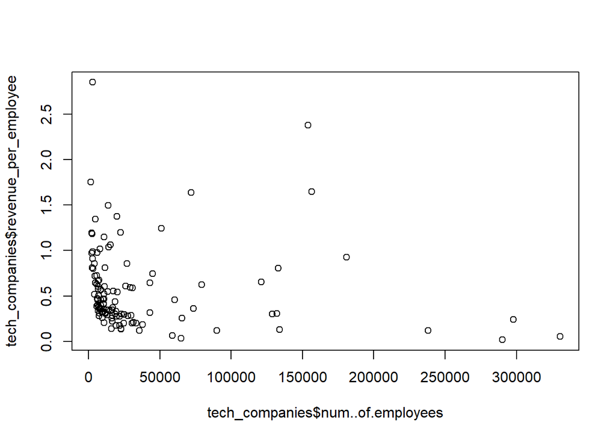

```r
plot(tech_companies$num..of.employees,tech_companies$revenue_per_employee)
```

### Analysis of the tech_companies dataset

#### We observe that the lowest revenue of tech_companies is DocuSign with the value of ‘2107.2’ and the company with the highest revenue with the value of ‘365817’ is Apple.

#### Also the company with the highest profit with the profit of ‘94680’ is Apple and a margin of ‘0.25881793’ and Splunk is the company with the lowest profit ‘-1339.1’ and a margin of ‘-0.5008415305’

#### Based on these observations, we can conclude that the technology industry is a highly variable and dynamic sector, with a wide range of companies and business models. Further analysis could be conducted to identify factors that are associated with high revenue, profit, and profit margins in this industry, such as the size of the company, the amount of investment in research and development, or the type of products or services offered.